# 705 HW1

2023-08-25

```r
library(magrittr)
library(dplyr)
```

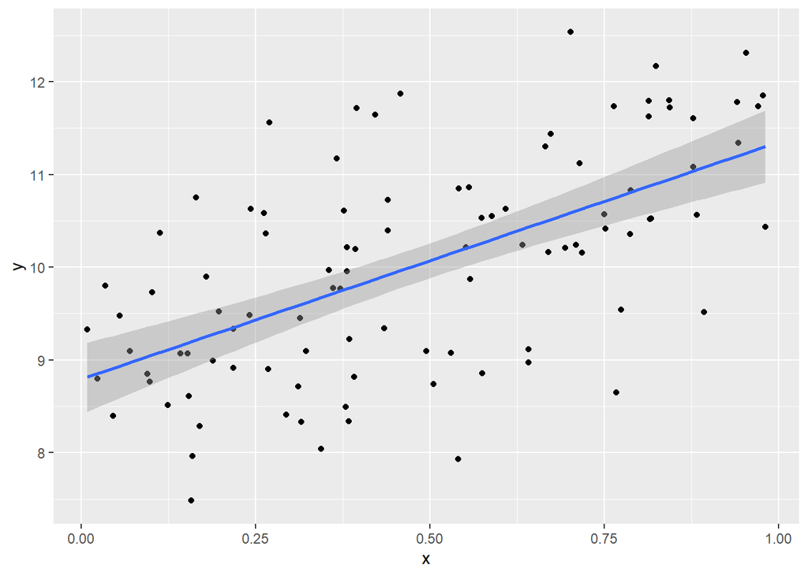

```r
library(ggplot2)
library(plotly)
set.seed(12)
xDF1 <- runif(100)  #how to simulate data before $>%
xDF1 %>% data.frame(y = 2*xDF1 + rnorm(100) + 9 , x=.) %>% ggplot(aes(x, y)) + geom_point() + geom_smooth(method='lm')
```

```r
NOBEL   <- read.table(url("https://raw.githubusercontent.com/dsy109/Supplemental/main/Courses/705/nobel.txt"),header = TRUE)
```

The output of the structure of the Nobel Prize:

```r
typeof(NOBEL)
```

```
## [1] "list"
```

Here the four variables has the following:

```r
class(NOBEL$prize_year)
```

```
## [1] "integer"
```

```r
class(NOBEL$category)
```

```
## [1] "character"
```

```r
typeof(NOBEL$gender)
```

```
## [1] "character"
```

```r
typeof(NOBEL$age)
```

```
## [1] "double"
```

2. For the missing age:

```r
NOBEL$category <- as.factor(NOBEL$category)
```

```r
table(NOBEL$category[which(is.na(NOBEL$age))])
```

```
##
##  Chemistry  Economics Literature   Medicine      Peace    Physics
##          1          1          0          0         27          1
```

For the missing gender:

```r
table(NOBEL$category[which(is.na(NOBEL$gender))])
```

```
##
##  Chemistry  Economics Literature   Medicine      Peace    Physics
##          0          0          0          0         26          0
```

The Peace has the most missing values for each of these variables.

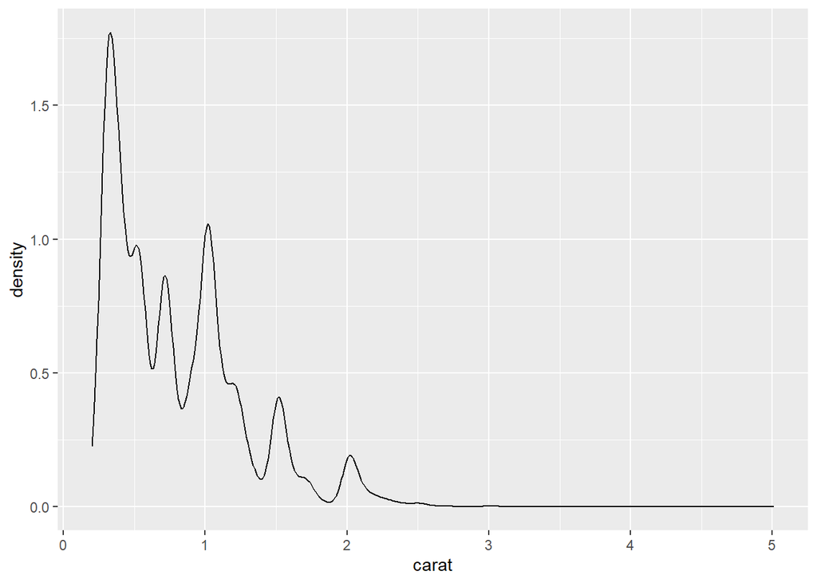

```r
ggplot(diamonds, aes(carat)) +
  geom_density()
```

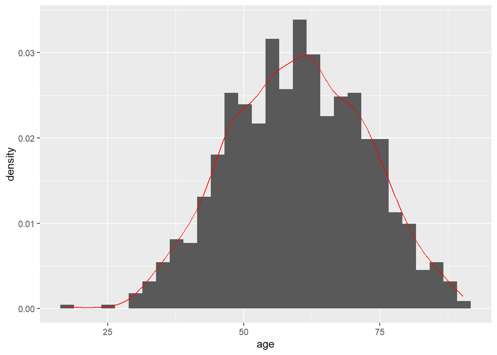

```r
ggplot(NOBEL, aes(x=age)) + geom_histogram(aes(y=..density..)) +   geom_density(color="red")
```

I think the distribution of ages is a like a normal distribution with mean around 58. Although has a little bit left skewed, but basically show a normal distribution.

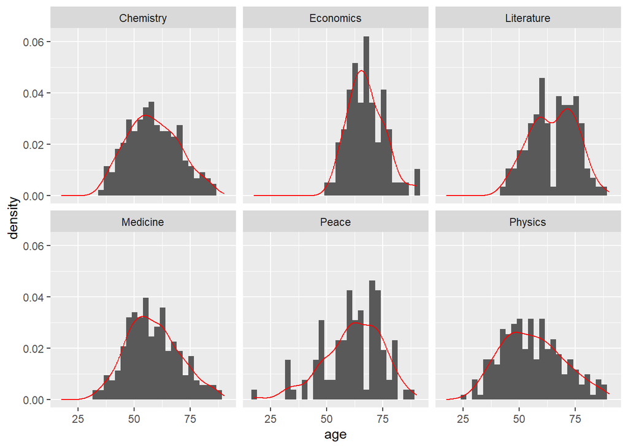

```r
ggplot(NOBEL, aes(x=age)) +
  geom_histogram(aes(y=..density..)) +
   facet_wrap(vars(category)) +
  geom_density(color="red")
```

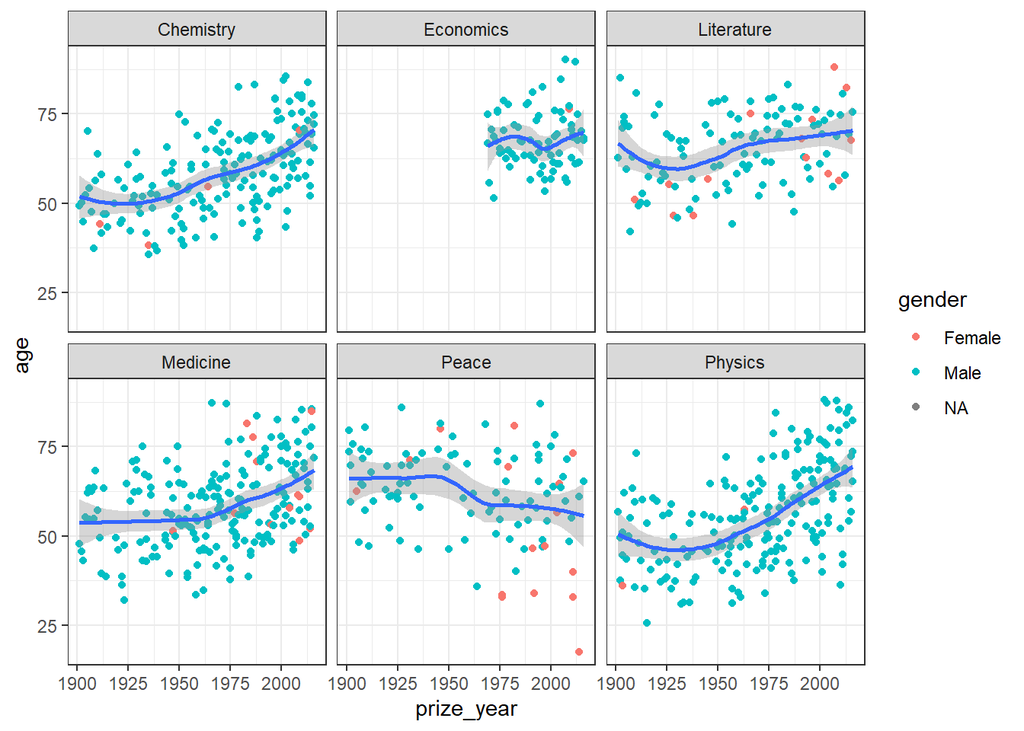

```r
base_size <- 11
ggplot(NOBEL, aes(x=prize_year,y =age  )) +
  geom_point(aes(colour=gender)) +
   facet_wrap(vars(category)) +
   geom_smooth(method = loess)+
   theme_bw(base_size = 11,
  base_line_size = base_size/22,
  base_rect_size = base_size/22
)
```

From the gender part, I notice that the men were the majority of the winners.

For the Chemistry, Medicine, Physics and Literature nobel prize, with the passage of time, the winner’s age is increasing. On the other hand, the winner of peace’s age is decreasing. Economic prize winner’s age shows fluctuate among different years.

```r
COVID   <- read.csv(url("https://raw.githubusercontent.com/dsy109/Supplemental/main/Courses/705/COVID.txt"), sep = "\t")
```

```r
first.digit  <- function(x) {
                a <- trunc(log10(x))+1

                return(trunc(x/10^(a-1)))

}
```

```r
power_32 <- 2^seq(1:1000)
mytable <- table(sapply(power_32, function(x) {
  first.digit(x)}))
```

```r
mytable/1000
```

```
##
##     1     2     3     4     5     6     7     8     9
## 0.301 0.176 0.125 0.097 0.079 0.069 0.056 0.052 0.045
```

```r
power_33 <- 3^seq(1:500)
mytable3 <- table(sapply(power_33, function(x) {
  first.digit(x)}))
```

```r
mytable3/500
```

```
##
##     1     2     3     4     5     6     7     8     9
## 0.300 0.176 0.124 0.098 0.080 0.066 0.058 0.052 0.046
```

```r
my_covid <- COVID$Deaths
```

```r
mytable4 <- table(sapply(my_covid, function(x) {
  first.digit(x)}))
```

```r
mytable4/192
```

```
##
##          1          2          3          4          5          6          7
## 0.38541667 0.14583333 0.13541667 0.07291667 0.04687500 0.07291667 0.05208333
##          8          9
## 0.05208333 0.03645833
```

```r
my_df5 <- data.frame(
  Leading_Digit = 1:9,
  two_power = mytable/1000,
  three_power = mytable3/500,
  Prop_COVID = mytable4/192
)
```

```r
my_df5$two_power.Var1 <- NULL

my_df5$three_power.Var1 <- NULL
my_df5$Prop_COVID.Var1 <- NULL
```

```r
my_df5$three_power.Freq
```

```
## [1] 0.300 0.176 0.124 0.098 0.080 0.066 0.058 0.052 0.046
```

```r
summary(lm(Prop_COVID.Freq~two_power.Freq + three_power.Freq ,data = my_df5))
```

```
##
## Call:
## lm(formula = Prop_COVID.Freq ~ two_power.Freq + three_power.Freq,
##     data = my_df5)
##
## Residuals:
##       Min        1Q    Median        3Q       Max
## -0.047534 -0.014814  0.001206  0.015904  0.028100
##
## Coefficients:
##                  Estimate Std. Error t value Pr(>|t|)
## (Intercept)      -0.02974    0.01653  -1.799    0.122
## two_power.Freq    6.76054    6.76793   0.999    0.356
## three_power.Freq -5.49290    6.80445  -0.807    0.450
##
## Residual standard error: 0.02751 on 6 degrees of freedom
## Multiple R-squared:  0.953,  Adjusted R-squared:  0.9373
## F-statistic: 60.84 on 2 and 6 DF,  p-value: 0.0001038
```

Here the $R^2$ is 0.953. The adjusted $R^2$ is 0.9373.

```r
p <- plot_ly(
  x = my_df5$two_power.Freq,
  y = my_df5$three_power.Freq ,
  z = my_df5$Prop_COVID.Freq,
  type = 'scatter3d' ,
  mode='lines',
  line = list(color = 'black')
)  %>% add_markers( data = my_df5,  color =  ~factor( Leading_Digit), mode = 'markers' ) %>%
  layout( title ='Benford’s Law Demonstration',scene = list(xaxis = list(title = 'First Digit (Powers of 2)'),
     yaxis = list(title = 'First Digit (Powers of 3)”'),  zaxis = list(title = 'First Digit (COVID Data)')
                                                            ))
```

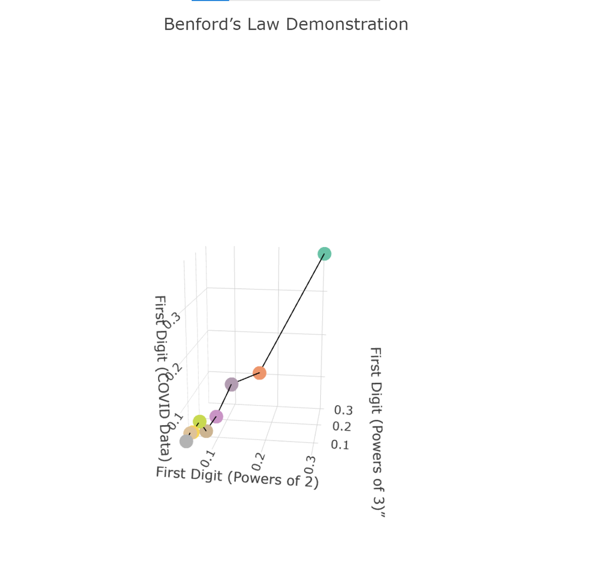

```r
knitr::include_graphics("Screenshot 2023-08-30 154216.png")
```

```r
library(HoRM)
data("tortoise")
```

Linear regression line:

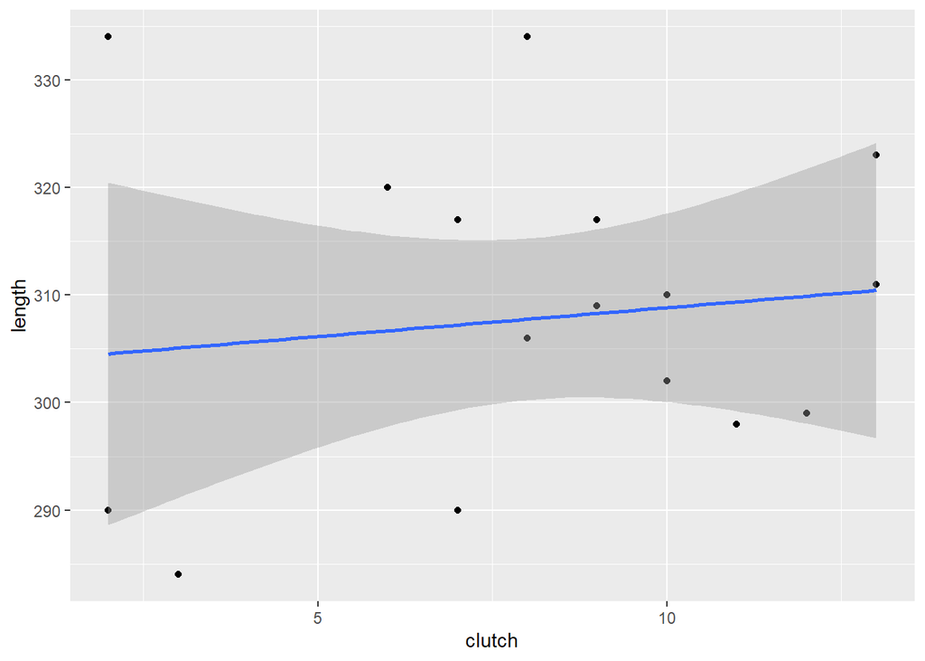

```r
ggplot(tortoise,aes(clutch, length)) +
  geom_point() +
  geom_smooth(method='lm')
```

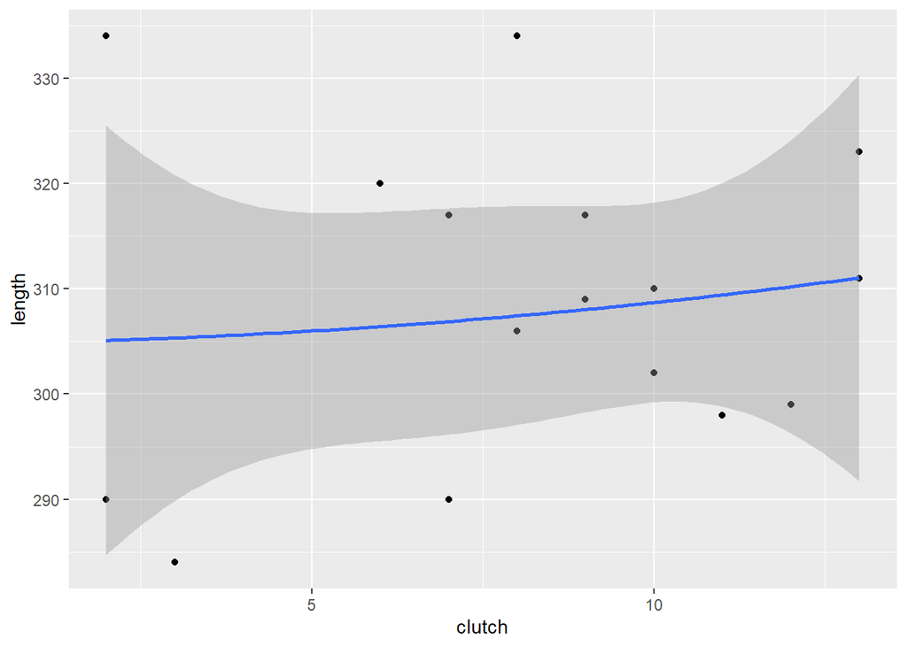

```r
ggplot(tortoise,aes(clutch, length)) +
  geom_point() +
  geom_smooth(method = "lm", formula = y ~ x + I(x^2))
```

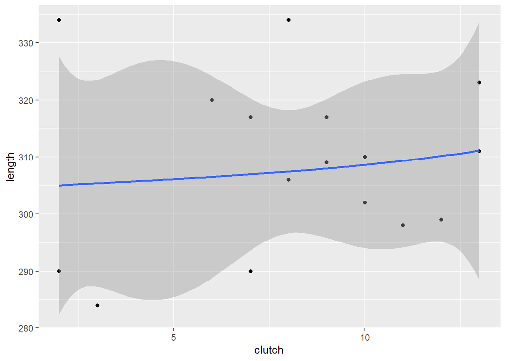

```r
ggplot(tortoise,aes(clutch, length)) +
  geom_point() +
  geom_smooth(method = "lm", formula = y ~ x + I(x^2)+I(x^3))
```

Here I get that the above 3 regression. Here I noticed that all the three regression show a increasing trend. Also, I notice that the linear regression seems has the least se. But it is difficult to deicde which is the best regression.

2. ANOVA:

```r
my_1 <-  lm(length ~ clutch,data = tortoise)
my_2 <-  lm(length ~ clutch + I(clutch^2),data = tortoise)
my_3 <-  lm(length ~ clutch + I(clutch^2)+I(clutch^3),data = tortoise)
```

```r
anova(my_1,my_2)
```

```
## Analysis of Variance Table
##
## Model 1: length ~ clutch
## Model 2: length ~ clutch + I(clutch^2)
##   Res.Df    RSS Df Sum of Sq      F Pr(>F)
## 1     16 3614.9
## 2     15 3612.5  1    2.3597 0.0098 0.9225
```

```r
anova(my_3,my_2)
```

```
## Analysis of Variance Table
##
## Model 1: length ~ clutch + I(clutch^2) + I(clutch^3)
## Model 2: length ~ clutch + I(clutch^2)
##   Res.Df    RSS Df Sum of Sq     F Pr(>F)
## 1     14 3612.5
## 2     15 3612.5 -1 -0.062546 2e-04 0.9878
```

```r
anova(my_1,my_3)
```

```
## Analysis of Variance Table
##
## Model 1: length ~ clutch
## Model 2: length ~ clutch + I(clutch^2) + I(clutch^3)
##   Res.Df    RSS Df Sum of Sq      F Pr(>F)
## 1     16 3614.9
## 2     14 3612.5  2    2.4223 0.0047 0.9953
```

Stepwise variable selection:

```r
step(my_3)
```

```
## Start:  AIC=103.43
## length ~ clutch + I(clutch^2) + I(clutch^3)
##
##               Df Sum of Sq    RSS    AIC
## - I(clutch^2)  1  0.009570 3612.5 101.43
## - I(clutch^3)  1  0.062546 3612.5 101.43
## - clutch       1  0.097341 3612.6 101.43
## <none>                     3612.5 103.43
##
## Step:  AIC=101.43
## length ~ clutch + I(clutch^3)
##
##               Df Sum of Sq    RSS     AIC
## - I(clutch^3)  1    2.4127 3614.9  99.444
## - clutch       1    2.5391 3615.0  99.445
## <none>                     3612.5 101.432
##
## Step:  AIC=99.44
## length ~ clutch
##
##          Df Sum of Sq    RSS    AIC
## - clutch  1    54.227 3669.1 97.712
## <none>                3614.9 99.444
##
## Step:  AIC=97.71
## length ~ 1
```

```
##
## Call:
## lm(formula = length ~ 1, data = tortoise)
##
## Coefficients:
## (Intercept)
##       307.8
```

Calculating the BIC

```r
step(my_3,k=log(length(tortoise$length)))
```

```
## Start:  AIC=106.99
## length ~ clutch + I(clutch^2) + I(clutch^3)
##
##               Df Sum of Sq    RSS    AIC
## - I(clutch^2)  1  0.009570 3612.5 104.10
## - I(clutch^3)  1  0.062546 3612.5 104.10
## - clutch       1  0.097341 3612.6 104.10
## <none>                     3612.5 106.99
##
## Step:  AIC=104.1
## length ~ clutch + I(clutch^3)
##
##               Df Sum of Sq    RSS    AIC
## - I(clutch^3)  1    2.4127 3614.9 101.22
## - clutch       1    2.5391 3615.0 101.22
## <none>                     3612.5 104.10
##
## Step:  AIC=101.22
## length ~ clutch
##
##          Df Sum of Sq    RSS     AIC
## - clutch  1    54.227 3669.1  98.602
## <none>                3614.9 101.225
##
## Step:  AIC=98.6
## length ~ 1
```

```
##
## Call:
## lm(formula = length ~ 1, data = tortoise)
##
## Coefficients:
## (Intercept)
##       307.8
```

Here I choose 3 different ways to select the best model. I find that based all these three test, these three model not shows a lot of difference. I think it agrees with the previous observation.